# Title: Reproducible Research

I split this assignment into two parts. This is the analysis of the data with the NA values omitted. The program name is ‘prog_01.Rmd’ with corresponding ‘prog_01.html’ file. =========================================================================

There is a second program that produces the analyis for data with the NAs replaced by the average for that interval over the two months. The program name is ‘prog_02.Rmd’ with corresponding ‘prog_02.html’ file.

==========================================================================

```r
    library(dplyr)
```

```r
    library(knitr)
    library(ggplot2)
```

Loading and preprocessing the data. Show any code that is needed to. Load the data (i.e. read.csv()). Process/transform the data (if necessary) into a format suitable for your analysis. ===================================================================================

The date and time were reformated. An new datetime column was created.

```r
    opts_chunk$set(echo = TRUE, results = 'hold')
    act_01   <-    read.csv("activity.csv", header=TRUE)
    summary(act_01)
```

```
##      steps                date          interval
##  Min.   :  0.00   2012-10-01:  288   Min.   :   0.0
##  1st Qu.:  0.00   2012-10-02:  288   1st Qu.: 588.8
##  Median :  0.00   2012-10-03:  288   Median :1177.5
##  Mean   : 37.38   2012-10-04:  288   Mean   :1177.5
##  3rd Qu.: 12.00   2012-10-05:  288   3rd Qu.:1766.2
##  Max.   :806.00   2012-10-06:  288   Max.   :2355.0
##  NA's   :2304     (Other)   :15840
```

```r
    head(act_01)
```

```
##   steps       date interval
## 1    NA 2012-10-01        0
## 2    NA 2012-10-01        5
## 3    NA 2012-10-01       10
## 4    NA 2012-10-01       15
## 5    NA 2012-10-01       20
## 6    NA 2012-10-01       25
```

```r
    NROW(act_01)
```

```
## [1] 17568
```

```r
    print (sapply(act_01, typeof))
```

```
##     steps      date  interval
## "integer" "integer" "integer"
```

```r
    act_02 <- filter(act_01)  %>% na.omit()
    NROW(act_02)
```

```
## [1] 15264
```

```r
    act_03 <- mutate(act_01, interval, na.rm=TRUE, date, steps,
                     Date_01 = format.Date(date, '%Y-%m-%d'),
                     Time_01 = paste0(substr(sprintf('%04d', interval), 1,2),                                               ':',
                                      substr(sprintf('%04d', interval), 3, 4)),
                     Datetime_01 =    as.POSIXct(paste0(Date_01, Time_01)))

    summary(act_03)
```

```
##      steps                date          interval       na.rm
##  Min.   :  0.00   2012-10-01:  288   Min.   :   0.0   Mode:logical
##  1st Qu.:  0.00   2012-10-02:  288   1st Qu.: 588.8   TRUE:17568
##  Median :  0.00   2012-10-03:  288   Median :1177.5   NA's:0
##  Mean   : 37.38   2012-10-04:  288   Mean   :1177.5
##  3rd Qu.: 12.00   2012-10-05:  288   3rd Qu.:1766.2
##  Max.   :806.00   2012-10-06:  288   Max.   :2355.0
##  NA's   :2304     (Other)   :15840
##    Date_01            Time_01           Datetime_01
##  Length:17568       Length:17568       Min.   :2012-10-01 00:00:00
##  Class :character   Class :character   1st Qu.:2012-10-16 05:58:45
##  Mode  :character   Mode  :character   Median :2012-10-31 11:57:30
##                                        Mean   :2012-10-31 11:30:52
##                                        3rd Qu.:2012-11-15 17:56:15
##                                        Max.   :2012-11-30 23:55:00
##
```

```r
    head(act_03)
```

```
##   steps       date interval na.rm    Date_01 Time_01         Datetime_01
## 1    NA 2012-10-01        0  TRUE 2012-10-01   00:00 2012-10-01 00:00:00
## 2    NA 2012-10-01        5  TRUE 2012-10-01   00:05 2012-10-01 00:05:00
## 3    NA 2012-10-01       10  TRUE 2012-10-01   00:10 2012-10-01 00:10:00
## 4    NA 2012-10-01       15  TRUE 2012-10-01   00:15 2012-10-01 00:15:00
## 5    NA 2012-10-01       20  TRUE 2012-10-01   00:20 2012-10-01 00:20:00
## 6    NA 2012-10-01       25  TRUE 2012-10-01   00:25 2012-10-01 00:25:00
```

```r
    NROW(act_03)
```

```
## [1] 17568
```

```r
    print (sapply(act_03, typeof))
```

```
##       steps        date    interval       na.rm     Date_01     Time_01
##   "integer"   "integer"   "integer"   "logical" "character" "character"
## Datetime_01
##    "double"
```

```r
    act_04 <- aggregate(steps ~ date, act_03, sum)

    colnames(act_04) <- c("Date","Steps")

    head(act_04)
```

```
##         Date Steps
## 1 2012-10-02   126
## 2 2012-10-03 11352
## 3 2012-10-04 12116
## 4 2012-10-05 13294
## 5 2012-10-06 15420
## 6 2012-10-07 11015
```

```r
    NROW(act_04)
```

```
## [1] 53
```

What is the mean total number of steps taken per day?

For this part of the assignment, you can ignore the missing values in the dataset.

Calculate the total number of steps taken per day.

# Here is a breakdown of the number of steps per day.

Each day has 24 x 12 five minute intervals = 288. There are 61 days from 1st October to 30 Nomember. NA values are excluded. ===================================================

```r
    kable(act_04)
```

```
##
##
## Date          Steps
## -----------  ------
## 2012-10-02      126
## 2012-10-03    11352
## 2012-10-04    12116
## 2012-10-05    13294
## 2012-10-06    15420
## 2012-10-07    11015
## 2012-10-09    12811
## 2012-10-10     9900
## 2012-10-11    10304
## 2012-10-12    17382
## 2012-10-13    12426
## 2012-10-14    15098
## 2012-10-15    10139
## 2012-10-16    15084
## 2012-10-17    13452
## 2012-10-18    10056
## 2012-10-19    11829
## 2012-10-20    10395
## 2012-10-21     8821
## 2012-10-22    13460
## 2012-10-23     8918
## 2012-10-24     8355
## 2012-10-25     2492
## 2012-10-26     6778
## 2012-10-27    10119
## 2012-10-28    11458
## 2012-10-29     5018
## 2012-10-30     9819
## 2012-10-31    15414
## 2012-11-02    10600
## 2012-11-03    10571
## 2012-11-05    10439
## 2012-11-06     8334
## 2012-11-07    12883
## 2012-11-08     3219
## 2012-11-11    12608
## 2012-11-12    10765
## 2012-11-13     7336
## 2012-11-15       41
## 2012-11-16     5441
## 2012-11-17    14339
## 2012-11-18    15110
## 2012-11-19     8841
## 2012-11-20     4472
## 2012-11-21    12787
## 2012-11-22    20427
## 2012-11-23    21194
## 2012-11-24    14478
## 2012-11-25    11834
## 2012-11-26    11162
## 2012-11-27    13646
## 2012-11-28    10183
## 2012-11-29     7047
```

# Take the column “steps” from the “act_04” dataset and make a histogram of it.

# Comments:

The histogram suggests a Gaussian distribution with a possible positive skew. The intervals with zero steps (during sleep) may need to be ommitted so that the data reflects true activity during the day-time.

The mean and median are pracically identical.

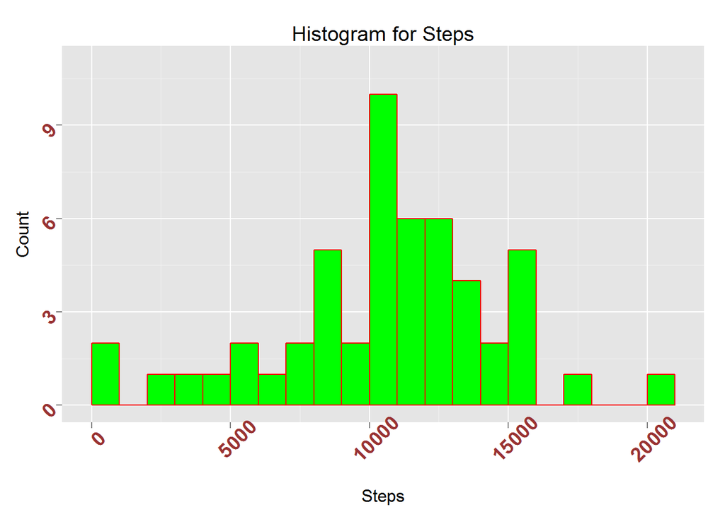

```r
    paddy_01 <- ggplot(data=act_04, aes(act_04$Steps)) +
                geom_histogram(breaks=seq(0, 21000, by = 1000),
                 col="red",
                 fill="green",
                 alpha = 1) +
  labs(title="Histogram for Steps") +
  labs(x="Steps", y="Count") +
  xlim(c(0,21000)) +
  ylim(c(0, 11))

    paddy_01 + theme(axis.text.x = element_text(face="bold", color="#993333",
                           size=14, angle=45),
                     axis.text.y = element_text(face="bold", color="#993333",
                           size=14, angle=45))
```

```r
    round(mean(act_04$Steps) )
    median(act_04$Steps)
```

```
## [1] 10766
## [1] 10765
```

What is the average daily activity pattern?

Make a time series plot (i.e. type = “l”) of the 5-minute interval (x-axis) and the average number of steps taken, averaged across all days (y-axis)

Which 5-minute interval, on average across all the days in the dataset, contains the maximum number of steps?

# Comments:

The data seems to make sense. People go to bed from 10pm onwards. Most people sleep between 12 midnight and 5am. People start getting up from 5am onwards and possibly walk to work. The data suggests a sedentary group of workers. There is a spike about lunch time. People leave work at different times or are involved in different activities in the evening. ========================================================================================

[figure not shown]

```r
    act_05 <- aggregate(steps ~ interval, act_03, sum)
    head(act_05)
    NROW(act_05)

    paddy_02 <- ggplot(act_05, aes(interval, steps)) + geom_line() +
                xlab("") + ylab("Average steps in 5 minute intervals")

    paddy_02
```

```r
    act_06 <- filter(act_05, steps, interval, steps == max(steps))
    head(act_06)
    NROW(act_06)
```

[output not shown]